# Markov Word Predictor

Eduardo Rodríguez  
April 22, 2016

### Word Prediction

- When you enter text on your smartphone, it offers you several alternatives for the next word you might want to type.
- Your keyboard app compares the words you have written with those in a text database, and searches for the next most likely word.
- This is called an “[n-gram](https://en.wikipedia.org/wiki/N-gram) model,” where n refers to the number of words used to predict the next one.
- We have built an n-gram model as an n-th order Markov chain, a process that undergoes transitions from one state to another with a given probability.

### The Shiny App

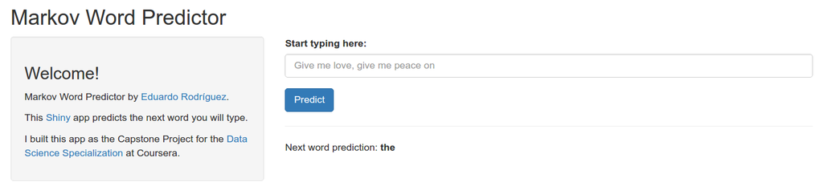

[Shiny app](https://nemarona.shinyapps.io/Markov_Word_Predictor/) hosted on the Shiny Apps server.  
Clean and simple interface:

1. Type some words
2. Hit Predict button
3. Get a prediction for the next word

### The Model

- Our model is an \( n \)-th order Markov chain, as suggested by [Ching et al. (2004)](http://dx.doi.org/10.1002/nav.20017).
- The state of the system at time \( t \) depends on the \( n \) previous states, \( X_{t} = \sum_{k=1}^{n} \lambda_{k} X_{t-k} Q_{k} \).
- Here, \( Q_{k} \) is a \( k \)-th order transition matrix, and \( \lambda_{k} \) are (positive) coefficients subject to \( \lambda_{1} + \cdots + \lambda_{n} = 1 \).
- The \( \lambda \)-coefficients are computed by minimizing \( \left\lVert \sum_{k=1}^{n} \lambda_{k} \hat{X} Q_{k} - \hat{X} \right\rVert \), where \( \hat{X} \) is the stationary distribution.

### Accuracy

- Testing against real texts yields 12% accuracy.
- Model size (25,000 words, 2nd order Markov chain) was limited by available computing power.
- A larger model would likely perform better, although size may be limited by speed concerns.
- Instead of relying on a “Predict” button, predict-as-you-type, [SwiftKey](https://swiftkey.com/)-style, should be faster and more accurate.
- A future model must be able to *learn* from the user.